Тестовое задание в sravni.ru  
Владимир Силкин  
07.11.2021

В данном ноутбуке я демонстрирую алгоритм построения предсказательной модели, ранжирующей наблюдения по вероятности принять целевое значение на основе 12 признаков (дохода, наличия детей, недвижимости, частной собственности и тд.).

Ноутбук включает в себя разведовательный анализ данных, выбор наилучшей модели, анализ ее качества и калибровку.

# Cодержание с гиперссылками!

- Libraries
- Task descriptions
- Train, Validation and Calibration sets - подготовка датасетов для обучения, тестирования и калибровки.
- Feature Engeneering - в колонках 'DCI', 'PROFIT_FAMILY' и 'UCI' оставим только значения ДО запятой.
- Exploratory Data Analysis
  - Class Ballance
  - Correlation Matrix
- Predicting
  - Classifier selection
  - Random Forest is the best classifier
  - Calibration of probability
- Prediction for test dataset
- Summary

# Libraries

```python
import numpy as np
import pandas as pd
from collections import defaultdict

import matplotlib.pyplot as plt
from matplotlib.gridspec import GridSpec
import seaborn as sns
%matplotlib inline

import xgboost

from sklearn import tree
from sklearn.model_selection import train_test_split, \
                                    cross_val_score, \
                                    GridSearchCV, \
                                    RandomizedSearchCV

from sklearn.linear_model import LogisticRegression
from sklearn.metrics import roc_curve, \
                            roc_auc_score, \
                            auc, \
                            classification_report, \
                            accuracy_score, \
                            confusion_matrix, \
                            recall_score, \
                            precision_score,\
                            f1_score,\
                            brier_score_loss

from sklearn.calibration import calibration_curve, \
                                CalibrationDisplay, \
                                CalibratedClassifierCV

from sklearn.ensemble import RandomForestClassifier, \
                             AdaBoostClassifier, \
                             GradientBoostingClassifier

from sklearn.neighbors import KNeighborsClassifier
from sklearn.neural_network import MLPClassifier
from sklearn.decomposition import PCA
```

# Task description

```python
df = pd.read_csv('Dataset_scoring.txt', sep = ';')
df.head()
```

|  | 2ID | SEX | CHILD_BOOL | REALTY_BOOL | HAVE_ACCOUNT_BOOL | EMAIL_BOOL | DCI | PROFIT_FAMILY | UCI | FOREIGN_PASSPORT_BOOL | SIML | EDUCATION | TRANSPORT_AMOUNT | target | sample |
| --- | --- | --- | --- | --- | --- | --- | --- | --- | --- | --- | --- | --- | --- | --- | --- |
| 0 | 2 | 1 | 1 | 1 | 0 | 0 | 28312,8594 | 33312,8594 | 0 | 1 | 19 | 3 | 2 | 1.0 | Train |
| 1 | 4 | 0 | 0 | 0 | 0 | 0 | 28738,4707 | 28738,4707 | 0 | 0 | 20 | 3 | 0 | 1.0 | Train |
| 2 | 6 | 1 | 1 | 1 | 0 | 0 | 25920,5195 | 37000 | 0 | 0 | 38 | 3 | 0 | 1.0 | Train |
| 3 | 7 | 1 | 0 | 1 | 1 | 0 | 0 | 16243,8096 | 7000 | 0 | 71 | 5 | 1 | 1.0 | Train |
| 4 | 8 | 1 | 1 | 1 | 0 | 0 | 17400 | 17400 | 0 | 0 | 59 | 3 | 3 | 1.0 | Train |

**Признаки:**

1. ID - ID клиента
2. SEX - пол (0 - женский, 1 - мужской)
3. CHILD_BOOL - признак наличия детей
4. REALTY_BOOL - признак наличия недвижимоси
5. HAVE_ACCOUNTS_BOOL - признак счета в банке
6. EMAIL_BOOL - признак наличия электронной почты
7. DCI - (Census Income) доход в руб.
8. PROFIT_FAMILY доход семьи в руб.
9. UCI - доход по неосновному месту работы в руб.
10. FOREIGN_PASSPORT_BOOL - признак наличия паспорта
11. SIML - стаж работы на последнем месте работы в мес.
12. EDUCATION - образование (-1 - не указано)
13. TRANSPORT_AMOUNT - количество ТС в собственности
14. **target - целевой признак (пустой для тестовой подвыборки)**
15. sample - обучающая/тестовая выборка

**Задача:**  
Построить модель скоринга, ранжирующего выборку по вероятности принять целевой признак значение = 1

**Будем строить предсказательную модель на основе 12 признаков.**  
Выкидываем "ID", "target" и "sample".

# Feature Engeneering

**В колонках 'DCI', 'PROFIT_FAMILY' и 'UCI' оставим только значения ДО запятой.**

```python
df = pd.read_csv('Dataset_scoring.txt', sep = ';')
df['DCI'] = df['DCI'].apply(lambda x: x.split(',')[0])
df['PROFIT_FAMILY'] = df['PROFIT_FAMILY'].apply(lambda x: x.split(',')[0])
df['UCI'] = df['UCI'].apply(lambda x: x.split(',')[0])
df['target'] = df['target']

df.head()
```

|  | 2ID | SEX | CHILD_BOOL | REALTY_BOOL | HAVE_ACCOUNT_BOOL | EMAIL_BOOL | DCI | PROFIT_FAMILY | UCI | FOREIGN_PASSPORT_BOOL | SIML | EDUCATION | TRANSPORT_AMOUNT | target | sample |
| --- | --- | --- | --- | --- | --- | --- | --- | --- | --- | --- | --- | --- | --- | --- | --- |
| 0 | 2 | 1 | 1 | 1 | 0 | 0 | 28312 | 33312 | 0 | 1 | 19 | 3 | 2 | 1.0 | Train |
| 1 | 4 | 0 | 0 | 0 | 0 | 0 | 28738 | 28738 | 0 | 0 | 20 | 3 | 0 | 1.0 | Train |
| 2 | 6 | 1 | 1 | 1 | 0 | 0 | 25920 | 37000 | 0 | 0 | 38 | 3 | 0 | 1.0 | Train |
| 3 | 7 | 1 | 0 | 1 | 1 | 0 | 0 | 16243 | 7000 | 0 | 71 | 5 | 1 | 1.0 | Train |
| 4 | 8 | 1 | 1 | 1 | 0 | 0 | 17400 | 17400 | 0 | 0 | 59 | 3 | 3 | 1.0 | Train |

# Train, Validation and Calibration sets

```python
train = df[df['sample'] == 'Train']
test = df[df['sample'] == 'Test']
```

**Сформируем следующие датасеты:**

- **train** я буду использовать для обучения
- **val (val_calib + val_final)** — для проверки качества модели
- **val_calib** — для калибровки
- **val_final** — для проверки откалиброванной модели и сравнения с неоткалиброванной.

```python
X_train = train.drop(['target', 'sample', '2ID'], axis = 1)
y_train = train['target']

X_train, X_val, y_train, y_val = train_test_split(X_train, y_train, test_size = 0.37, random_state = 42)
X_val_calib, X_val_final, y_val_calib, y_val_final = train_test_split(X_val, y_val, test_size = 0.37, random_state = 42)

print('Количество элементов в датасетах:')
print('train:', X_train['SEX'].count())
print('val:', X_val['SEX'].count())
print('val_calib:', X_val_calib['SEX'].count())
print('val_final:', X_val_final['SEX'].count())
```

```
Количество элементов в датасетах:
train: 953
val: 560
val_calib: 352
val_final: 208
```

# Exploratory data analysis

## Class ballance

```python
print('Количество элементов двух классов на трейне:')
print('1_train:', train['target'].sum())
print('0_train:', train['target'].count() - train['target'].sum())
```

```
Количество элементов двух классов на трейне:
1_train: 757.0
0_train: 756.0
```

**Обучающая выборка сбалансирована по классам!**

## Correlation Matrix

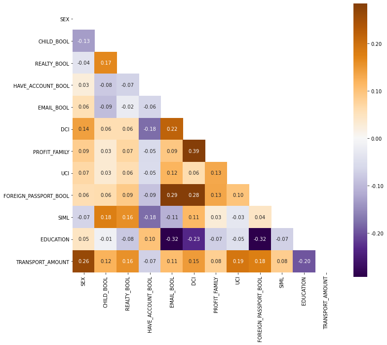

```python
corr_mtrx = X_train.corr()
#Mask the upper triangle:
mask = np.triu(np.ones(corr_mtrx.shape),0)

fig, ax = plt.subplots(figsize = (12,12))
ax = sns.heatmap(
    data = corr_mtrx,
    cmap = 'PuOr_r',
    center = 0,
    robust = True,
    annot = True,
    fmt = '.2f',
    square = True,
    cbar_kws = {'shrink': .85,
                'format': '%.2f'},
    mask = mask)
```

**Вывод: У нас нет ни одной пары сильно скоррелированных фичей! Это здорово!**

# Predicting

## Сlassifier selection

Функция принимает на вход трейн и тест датасеты. Для 6 алгоритмов:

подбирает наилучшие параметры с помощью RandomizedSearchCV и выводит результаты в виде датафрейма с основными метриками:

- Accuracy
- Sensitivity (TPR)
- Specifity (TNR)
- Precision
- F1-score (harmonic mean between Precision and Sensitivity)
- ROC AUC

```python
def all_clf(X_train, y_train, X_test, y_test):

#   1. Логистическая регрессия
    lr = LogisticRegression(penalty = 'l2',
                            max_iter = 30000)
    lr.fit(X_train, y_train)

#   2. RandomForest
    clf_rf = RandomForestClassifier()
    parameters_rf = {'min_samples_leaf': [5, 10, 15],
                     'max_features': [3],
                     'n_estimators': [100],
                     'max_depth': [5, 7, 10, 12, 15]}

    grid_search_cv_clf_rf = RandomizedSearchCV(clf_rf, parameters_rf, cv = 5, n_jobs = -1)
    grid_search_cv_clf_rf.fit(X_train, y_train)
    best_clf_rf = grid_search_cv_clf_rf.best_estimator_

#   3. GradientBoosting
    clf_gb = GradientBoostingClassifier()
    parameters_gb = { 'min_samples_leaf': [5, 10, 15],
                      'max_features': [3],
                      'n_estimators': [100],
                      'max_depth': [3, 5, 7, 10, 12]}
    grid_search_cv_clf_gb = RandomizedSearchCV(clf_gb, parameters_gb, cv = 5, n_jobs = -1)
    grid_search_cv_clf_gb.fit(X_train, y_train)
    best_clf_gb = grid_search_cv_clf_gb.best_estimator_

#   4. XGB-classifier
    clf_xgb = xgboost.XGBClassifier(use_label_encoder = False, eval_metric = 'mlogloss')
    parameters_xgb = {"learning_rate"    : [0.05, 0.10, 0.15, 0.20, 0.25, 0.30 ],
                      "max_depth"        : [ 3, 4, 5, 6, 8, 10, 12, 15],
                      "min_child_weight" : [ 1, 3, 5, 7 ],
                      "gamma"            : [ 0.0, 0.1, 0.2 , 0.3, 0.4 ],
                      "colsample_bytree" : [ 0.3, 0.4, 0.5 , 0.7 ] }
    grid_search_cv_clf_xgb = RandomizedSearchCV(clf_xgb, parameters_xgb, cv = 5, n_jobs = -1)
    grid_search_cv_clf_xgb.fit(X_train, y_train)
    best_clf_xgb = grid_search_cv_clf_xgb.best_estimator_

#   5. K-neighbour classifier
    clf_knn = KNeighborsClassifier()
    parameters_knn = {'n_neighbors': np.arange(1, 50, 1),
                      'weights': ['uniform', 'distance']}
    grid_search_cv_clf_knn = RandomizedSearchCV(clf_knn, parameters_knn, cv = 5, n_jobs = -1)
    grid_search_cv_clf_knn.fit(X_train, y_train)
    best_clf_knn = grid_search_cv_clf_knn.best_estimator_

#   6. Neural network
    clf_nn = MLPClassifier(max_iter = 3000)
    parameters_nn = {'hidden_layer_sizes': [5, 10, 15, 20, 25, 30, 35, 40]}
    grid_search_cv_clf_nn = GridSearchCV(clf_nn, parameters_nn, cv = 5)
    grid_search_cv_clf_nn.fit(X_train, y_train)
    best_clf_nn = grid_search_cv_clf_nn.best_estimator_


    clf_list = [(lr, "Logistic"),
                (best_clf_rf, "Random Forest"),
                (best_clf_gb, "Gradient Boosting"),
                (best_clf_xgb, "XGBoost"),
                (best_clf_knn, "KNN"),
                (best_clf_nn, "Neural Network"),
    ]

    scores = defaultdict(list)
    for i, (clf, name) in enumerate(clf_list):
        scores["Classifier"].append(name)
        scores["Accuracy"].append(accuracy_score(y_test, clf.predict(X_test)))
        scores["Sensitivity (TPR)"].append(recall_score(y_test, clf.predict(X_test)))
        scores["Specifity (TNR)"].append(recall_score(y_test, clf.predict(X_test), pos_label = 0))
        scores["Precision"].append(precision_score(y_test, clf.predict(X_test)))
        scores["F1-score"].append(f1_score(y_test, clf.predict(X_test)))
        scores["ROC AUC"].append(roc_auc_score(y_test, clf.predict_proba(X_test)[:, 1]))
        score_df = pd.DataFrame(scores).set_index("Classifier")
        score_df.round(decimals = 3)
    return score_df
```

```python
all_clf(X_train, y_train, X_val, y_val)
```

| Classifier | Accuracy | Sensitivity (TPR) | Specifity (TNR) | Precision | F1-score | ROC AUC |
| --- | --- | --- | --- | --- | --- | --- |
| Logistic | 0.517857 | 0.061151 | 0.968085 | 0.653846 | 0.111842 | 0.622238 |
| Random Forest | 0.666071 | 0.690647 | 0.641844 | 0.655290 | 0.672504 | 0.710189 |
| Gradient Boosting | 0.621429 | 0.669065 | 0.574468 | 0.607843 | 0.636986 | 0.675111 |
| XGBoost | 0.651786 | 0.669065 | 0.634752 | 0.643599 | 0.656085 | 0.704143 |
| KNN | 0.573214 | 0.579137 | 0.567376 | 0.568905 | 0.573975 | 0.595439 |
| Neural Network | 0.466071 | 0.428058 | 0.503546 | 0.459459 | 0.443203 | 0.447765 |

Из таблицы видно, что лучшие метрики показывают ансамблевые методы, среди которых **лидирует Random Forest**.

Логистическая регрессия, KNN и нейронные сети в пролете. Я не исключаю, что подобное поведение вызвано минимальной предобработакой данных.

## Random Forest is the best classifier

```python
clf_rf = RandomForestClassifier()
parameters_rf = {'min_samples_leaf': [15, 20, 25, 30, 35, 40, 45, 50, 100],
                 'max_features': [3, 4],
                 'n_estimators': [50, 75, 100],
                 'max_depth': [5, 7, 10, 12]}

grid_search_cv_clf_rf = GridSearchCV(clf_rf, parameters_rf, cv = 3, n_jobs = -1)
grid_search_cv_clf_rf.fit(X_train, y_train)
best_clf_rf = grid_search_cv_clf_rf.best_estimator_

print("The best params are:", grid_search_cv_clf_rf.best_params_)
```

```
The best params are: {'max_depth': 12, 'max_features': 3, 'min_samples_leaf': 35, 'n_estimators': 100}
```

Посмотрим метрики на тесте и трейне!

```python
xy_list = [(X_train, y_train),
          (X_val, y_val)]
scores = defaultdict(list)
for (x, y) in xy_list:
    scores["Accuracy"].append(accuracy_score(y, best_clf_rf.predict(x)))
    scores["Sensitivity (TPR)"].append(recall_score(y, best_clf_rf.predict(x)))
    scores["Specifity (TNR)"].append(recall_score(y, best_clf_rf.predict(x), pos_label = 0))
    scores["Precision"].append(precision_score(y, best_clf_rf.predict(x)))
    scores["F1-score"].append(f1_score(y, best_clf_rf.predict(x)))
    scores["ROC AUC"].append(roc_auc_score(y, best_clf_rf.predict_proba(x)[:, 1]))
    score_df = pd.DataFrame(scores, index = ('Random Forest (Train)', 'Random Forest (Validation)'))
    score_df.round(decimals = 3)
score_df
```

|  | Accuracy | Sensitivity (TPR) | Specifity (TNR) | Precision | F1-score | ROC AUC |
| --- | --- | --- | --- | --- | --- | --- |
| Random Forest (Train) | 0.698846 | 0.718163 | 0.679325 | 0.693548 | 0.705641 | 0.759216 |
| Random Forest (Validation) | 0.653571 | 0.658273 | 0.648936 | 0.648936 | 0.653571 | 0.715700 |

Наблюдается небольшое переобучение, но это нестрашно.

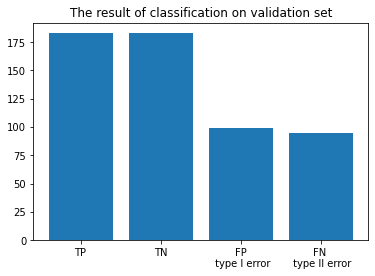

```python
m = confusion_matrix(y_true = y_val, y_pred = best_clf_rf.predict(X_val))
data = pd.DataFrame({'number': [m[1][1], m[0][0], m[0][1], m[1][0]],
                    'type': ['TP', 'TN', 'FP\n type I error', 'FN \n type II error']})
# data['number'] = data['number']/data['number'].sum()

fig = plt.figure()
plt.bar(data['type'], height = data['number'])
plt.title('The result of classification on validation set')
plt.show()
```

С помощью выбора порога принятия решения можно уменьшить либо количество FP (False Positives) за счет FN (False Negatives), либо наоборот — зависимости от того, что нужно бизнесу.

## Calibration of probability

В этом разделе мы проведем калибровку по специально подготовленному для нее **датасету**.

**Калибровка нужна для того, чтобы выходы алгоритма (числа от 0 до 1), действительно, имели смысл вероятностей!**

```python
# Функция принимает на вход массив реальных значений целовой переменной
# и массив предсказанных вероятностей. Возвращает одно число, характеризующее
# качество калибровки.

def expected_calibration_error(y, proba, bins = 'fd'):
    bin_count, bin_edges = np.histogram(proba, bins = bins)
    n_bins = len(bin_count)
    bin_edges[0] -= 1e-8 # because left edge is not included
    bin_id = np.digitize(proba, bin_edges, right = True) - 1
    bin_ysum = np.bincount(bin_id, weights = y, minlength = n_bins)
    bin_probasum = np.bincount(bin_id, weights = proba, minlength = n_bins)
    bin_ymean = np.divide(bin_ysum, bin_count, out = np.zeros(n_bins), where = bin_count > 0)
    bin_probamean = np.divide(bin_probasum, bin_count, out = np.zeros(n_bins), where = bin_count > 0)
    ece = np.abs((bin_probamean - bin_ymean) * bin_count).sum() / len(proba)
    return ece
```

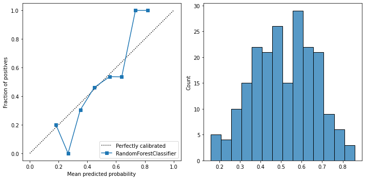

```python
fig = plt.figure(figsize = (10, 5))
gs = GridSpec(1, 2)
colors = plt.cm.get_cmap("Dark2")

ax_calibration_curve = fig.add_subplot(gs[0, 0])
disp = CalibrationDisplay.from_estimator(best_clf_rf, X_val_final, y_val_final, n_bins = 10, ax = ax_calibration_curve)

ax = fig.add_subplot(gs[0, 1])
probs = best_clf_rf.predict_proba(X_val_final)[:, 1]
sns.histplot(data = probs, binwidth = 0.05, ax = ax)

plt.tight_layout()
plt.show()
```

Выше представлены кривая калибровки и распределение вероятностей на итоговом сете (val_final) **ДО проведения калибровки**

```python
print("ECE: %1.5f" % expected_calibration_error(y_val_final, probs))
```

```
ECE: 0.08466
```

Expected Calibration Error (ECE) характеризует ошибку калибровки.

```python
# Калибруем модель на калибровочном датасете
calibrated_clf_rf = CalibratedClassifierCV(base_estimator = best_clf_rf,
                                           method = "sigmoid",
                                           cv = "prefit")
calibrated_clf_rf.fit(X_val_calib, y_val_calib);
```

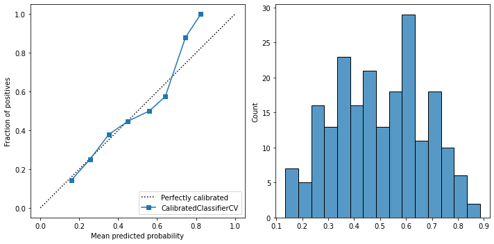

```python
fig = plt.figure(figsize = (10, 5))
gs = GridSpec(1, 2)
colors = plt.cm.get_cmap("Dark2")

ax_1 = fig.add_subplot(gs[0, 0])
disp_cal = CalibrationDisplay.from_estimator(calibrated_clf_rf, X_val_final, y_val_final, n_bins = 10, ax = ax_1)

ax_2 = fig.add_subplot(gs[0, 1])
probs_cal = calibrated_clf_rf.predict_proba(X_val_final)[:, 1]
sns.histplot(data = probs_cal, binwidth = 0.05, ax = ax_2)

plt.tight_layout()
plt.show()
```

Выше представлены кривая калибровки и распределение вероятностей на итоговом сете (val_final) **ПОСЛЕ проведения калибровки**!

```python
print("ECE: %1.5f" % expected_calibration_error(y_val_final, probs_cal))
```

```
ECE: 0.05389
```

**Ошибка упала в полтора раза.**  
Итоговый алгоритм характеризуется недостаточной уверенностью для предсказаний высокой вероятности. То есть если алгоритм предсказывает вероятность 0.8, то, судя по кривой калибровки,стоит ожидать, что реальная вероятность 0.9 или 0.95.

# Predictions for test dataset

```python
test.head()
```

|  | 2ID | SEX | CHILD_BOOL | REALTY_BOOL | HAVE_ACCOUNT_BOOL | EMAIL_BOOL | DCI | PROFIT_FAMILY | UCI | FOREIGN_PASSPORT_BOOL | SIML | EDUCATION | TRANSPORT_AMOUNT | target | sample |
| --- | --- | --- | --- | --- | --- | --- | --- | --- | --- | --- | --- | --- | --- | --- | --- |
| 1513 | 1 | 1 | 0 | 1 | 0 | 1 | 14370.0 | 14370.0 | 0.0 | 0 | 26 | 3 | 1 | NaN | Test |
| 1514 | 3 | 1 | 0 | 0 | 0 | 1 | 34729.0 | 34729.0 | 0.0 | 0 | 66 | 3 | 0 | NaN | Test |
| 1515 | 5 | 0 | 1 | 0 | 0 | 0 | 73310.0 | 73310.0 | 0.0 | 0 | 25 | 3 | 0 | NaN | Test |
| 1516 | 9 | 1 | 1 | 1 | 0 | 0 | 33383.0 | 48383.0 | 0.0 | 0 | 228 | 5 | 0 | NaN | Test |
| 1517 | 13 | 1 | 0 | 1 | 0 | 0 | 16504.0 | 36000.0 | 0.0 | 0 | 90 | 6 | 1 | NaN | Test |

```python
test = df[df['sample'] == 'Test']
X_test = test.drop(['sample', 'target', '2ID'], axis = 1)

out = pd.DataFrame({'ID': test['2ID'],
'Probabilities': best_clf_rf.predict_proba(X_test)[:, 1]}).sort_values(['Probabilities'], ascending = False)
out
```

|  | ID | Probabilities |
| --- | --- | --- |
| 2007 | 1672 | 0.868582 |
| 1686 | 585 | 0.868508 |
| 1674 | 554 | 0.855269 |
| 1729 | 733 | 0.851691 |
| 1989 | 1618 | 0.851201 |
| ... | ... | ... |
| 1660 | 505 | 0.150622 |
| 1881 | 1235 | 0.148914 |
| 1528 | 53 | 0.144354 |
| 2079 | 1902 | 0.135192 |
| 1721 | 711 | 0.130959 |

649 rows × 2 columns

Известны метрики этого классификатора и качество его калибровки.

Есть все основания полагать, что обучение модели на всём train-датасете (1513 наблюдений) могло бы увеличить метрики качества классификации за счет большего набора данных, при этом "откалиброванность" модели пострадала бы не сильно.

# **Summary**